# Proyecto Predict House Prices

José Abril - Diego Alvarez - Oswaldo López

2024-07-01

# Presentación de proyecto de Predict House Prices en Kaggle

En este proyecto se abordaron todos los temas vistos en clase para mejorar el RMSE a la hora de entrenar un modelo de predicción sobre la variable “median_house_value”.

```r
suppressPackageStartupMessages({
  library(tidyverse)
  library(caret)
  library(lightgbm)
  library(GGally)
  library(caretEnsemble)
  library(dplyr)
  library(ggplot2)
  library(caret)
  library(lubridate)
  library(PerformanceAnalytics)
  library(gridExtra)
  library(glmnet)
  library(MASS)
  library(gridExtra)
})
```

```r
# Cargar los datasets
train <- read.csv("../train.csv")
test <- read.csv("../data.csv")
```

Veamos que tiene el dataset:

```r
head(train)
```

```
##      id longitude latitude housing_median_age total_rooms total_bedrooms
## 1  9744   -121.65    36.77                 15        2191            358
## 2 13893   -116.27    34.13                 37         452            109
## 3 18277   -122.07    37.34                 35        1172            184
## 4 16176   -122.39    37.74                 52         126             24
## 5  8843   -118.38    34.09                 28        4001           1352
## 6  7653   -118.27    33.83                 28        2152            415
##   population households median_income median_house_value ocean_proximity
## 1       1150        330        4.7969             227500       <1H OCEAN
## 2        184         59        3.7292              65800          INLAND
## 3        512        175        7.3561             500001       <1H OCEAN
## 4         37         27       10.2264             225000        NEAR BAY
## 5       1799       1220        2.5784             272900       <1H OCEAN
## 6       1623        429        4.3500             200500       <1H OCEAN
```

Vemos todas las variables posibles a utilizar y nuestra Y llamada “median_house_value”. Con esto en mente vamos a visualizar nuestros datos y separarlos entre continuos y categóricos.

```r
yname = "median_house_value"
continuas =  names(train)[sapply(train, is.numeric) & names(train) != "median_house_value" & names(train) != "id"  &   30 < sapply(train, n_distinct)  ]
continuas
```

```
## [1] "longitude"          "latitude"           "housing_median_age"
## [4] "total_rooms"        "total_bedrooms"     "population"
## [7] "households"         "median_income"
```

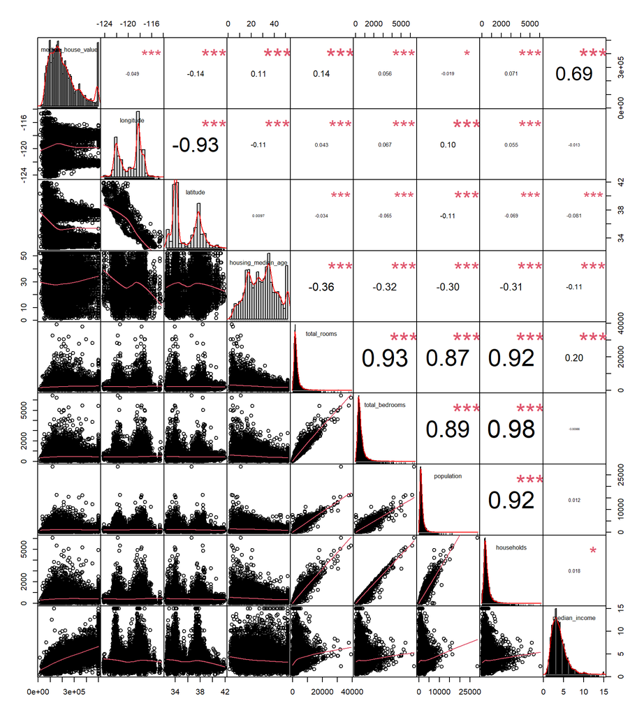

```r
suppressWarnings(chart.Correlation(train[c(yname,continuas)], histogram=TRUE))
```

Vimos cómo están distribuidos los valores y su correlación. Aislando solo la correlación se ve lo siguiente:

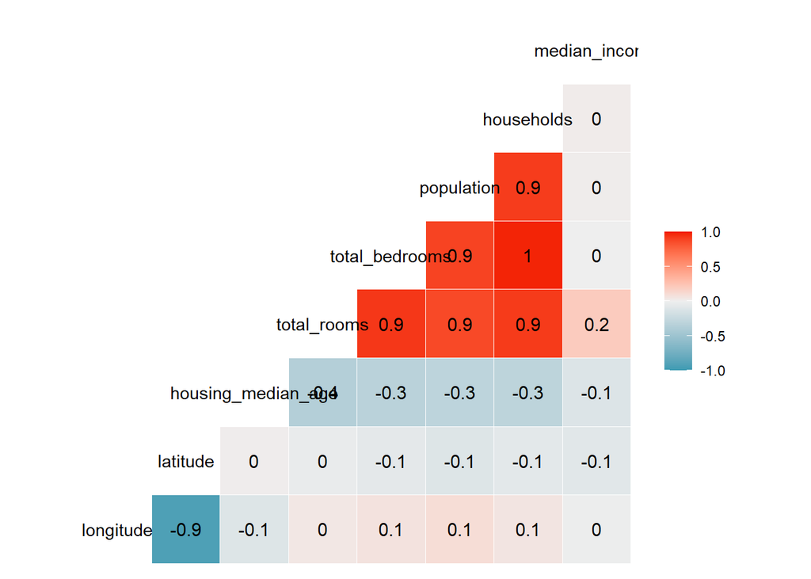

```r
# Correlación entre las variables numéricas
ggcorr(train[continuas], label = TRUE)
```

Aqui observamos la alta correlación con median_inc, una variable importante. Y luego la correlación entre las otras variables.

Ahora, con las categóricas:

Codificamos las variables categóricas para ser analizadas.

```r
# Codificar variables categóricas
train$ocean_proximity <- as.factor(train$ocean_proximity)
test$ocean_proximity <- as.factor(test$ocean_proximity)

unique(train$ocean_proximity)
```

```
## [1] <1H OCEAN  INLAND     NEAR BAY   NEAR OCEAN ISLAND
## Levels: <1H OCEAN INLAND ISLAND NEAR BAY NEAR OCEAN
```

Esto no es visualmente en el dataframe, pero si lo transforma a la hora de analizarlo correctamente.

Ahora veamos los datos como tal:

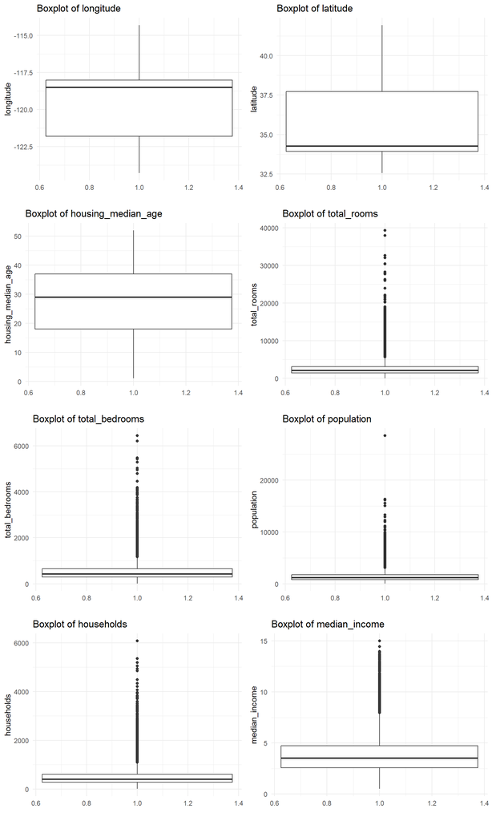

```r
# Función para crear un boxplot para una columna específica
create_boxplot <- function(column_name) {
  ggplot(train, aes_string(x = "1", y = column_name)) +  # Usamos aes_string para la evaluación no estándar
    geom_boxplot() +
    labs(title = paste("Boxplot of", column_name), x = "", y = column_name) +
    theme_minimal()
}

# Generar y mostrar todos los boxplots
plots <- lapply(c(continuas), create_boxplot)
do.call(grid.arrange, c(plots, ncol = 2))
```

Con esto vemos que tenemos bastantes valores outliers.

Veamos la cantidad de valores nulos:

```r
na_counts = colSums(is.na(train))

na_counts
```

```
##                 id          longitude           latitude housing_median_age
##                  0                  0                  0                  0
##        total_rooms     total_bedrooms         population         households
##                  0                137                  0                  0
##      median_income median_house_value    ocean_proximity
##                  0                  0                  0
```

Se identificó la variable total_bedrooms con valores nulos. Procedemos a usar la mediana de esos valores.

```r
# Imputar valores nulos en total_bedrooms
train$total_bedrooms[is.na(train$total_bedrooms)] <- median(train$total_bedrooms, na.rm = TRUE)
test$total_bedrooms[is.na(test$total_bedrooms)] <- median(test$total_bedrooms, na.rm = TRUE)
```

```r
na_counts = colSums(is.na(train))

na_counts
```

```
##                 id          longitude           latitude housing_median_age
##                  0                  0                  0                  0
##        total_rooms     total_bedrooms         population         households
##                  0                  0                  0                  0
##      median_income median_house_value    ocean_proximity
##                  0                  0                  0
```

### Ingeniería de características

Dentro del proceso de análisis, decidimos crear nuevas características

```r
# Ingeniería de características
train <- train %>%
  mutate(
    rooms_per_household = total_rooms / households,
    bedrooms_per_room = total_bedrooms / total_rooms,
    population_per_household = population / households
  )

test <- test %>%
  mutate(
    rooms_per_household = total_rooms / households,
    bedrooms_per_room = total_bedrooms / total_rooms,
    population_per_household = population / households
  )

head(train)
```

```
##      id longitude latitude housing_median_age total_rooms total_bedrooms
## 1  9744   -121.65    36.77                 15        2191            358
## 2 13893   -116.27    34.13                 37         452            109
## 3 18277   -122.07    37.34                 35        1172            184
## 4 16176   -122.39    37.74                 52         126             24
## 5  8843   -118.38    34.09                 28        4001           1352
## 6  7653   -118.27    33.83                 28        2152            415
##   population households median_income median_house_value ocean_proximity
## 1       1150        330        4.7969             227500       <1H OCEAN
## 2        184         59        3.7292              65800          INLAND
## 3        512        175        7.3561             500001       <1H OCEAN
## 4         37         27       10.2264             225000        NEAR BAY
## 5       1799       1220        2.5784             272900       <1H OCEAN
## 6       1623        429        4.3500             200500       <1H OCEAN
##   rooms_per_household bedrooms_per_room population_per_household
## 1            6.639394         0.1633957                 3.484848
## 2            7.661017         0.2411504                 3.118644
## 3            6.697143         0.1569966                 2.925714
## 4            4.666667         0.1904762                 1.370370
## 5            3.279508         0.3379155                 1.474590
## 6            5.016317         0.1928439                 3.783217
```

Veamos los datos post ingeniería de características.

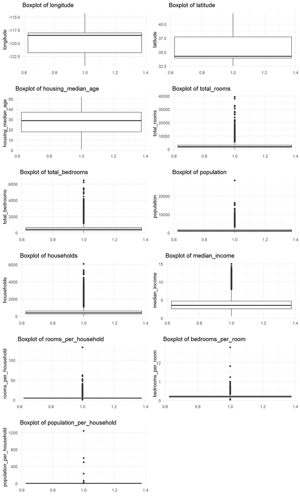

```r
# Función para crear un boxplot para una columna específica
create_boxplot <- function(column_name) {
  ggplot(train, aes_string(x = "1", y = column_name)) +  # Usamos aes_string para la evaluación no estándar
    geom_boxplot() +
    labs(title = paste("Boxplot of", column_name), x = "", y = column_name) +
    theme_minimal()
}

# Generar y mostrar todos los boxplots
plots <- lapply(c(continuas, "rooms_per_household", "bedrooms_per_room", "population_per_household"), create_boxplot)

do.call(grid.arrange, c(plots, ncol = 2))
```

```r
# Escalar características numéricas
num_features <- names(train)[sapply(train, is.numeric) & names(train) != "median_house_value" & names(train) != "id"]
preProcValues <- preProcess(train[, num_features], method = c("center", "scale"))
train_processed <- train
train_processed[, num_features] <- predict(preProcValues, train[, num_features])
test_processed <- test
test_processed[, num_features] <- predict(preProcValues, test[, num_features])
```

Veamos cómo quedaron despues de normalizarlos.

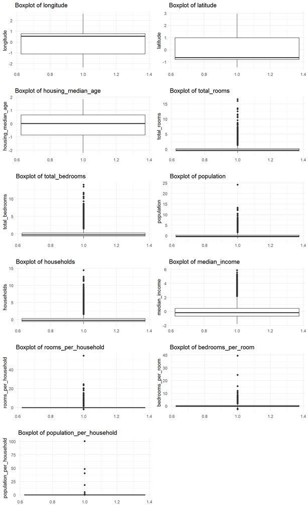

```r
# Función para crear un boxplot para una columna específica
create_boxplot <- function(column_name) {
  ggplot(train_processed, aes_string(x = "1", y = column_name)) +  # Usamos aes_string para la evaluación no estándar
    geom_boxplot() +
    labs(title = paste("Boxplot of", column_name), x = "", y = column_name) +
    theme_minimal()
}

# Generar y mostrar todos los boxplots
plots <- lapply(c(continuas, "rooms_per_household", "bedrooms_per_room", "population_per_household"), create_boxplot)

do.call(grid.arrange, c(plots, ncol = 2))
```

Dejamos los outliers para permitir al modelo entrenarse con esos datos. Y que sea capaz de predecirlos.

## Entrenamiento del Modelo

#### Pre procesamiento de los datos

```r
# Seleccionar características
selected_features <- c(num_features, "ocean_proximity")

# Preparar los datos para LightGBM
dtrain <- lgb.Dataset(data = as.matrix(train_processed[, selected_features]), label = train_processed$median_house_value)
```

#### Entrenamiento del modelo LightGBM

```r
# Parámetros de LightGBM
params <- list(
  objective = "regression",
  metric = "rmse",
  boosting_type = "gbdt",
  learning_rate = 0.01,
  num_leaves = 31,
  feature_fraction = 0.9,
  bagging_fraction = 0.8,
  bagging_freq = 5,
  verbose = -1
)

# Entrenar el modelo
set.seed(123)
model_lgb <- lgb.train(params, dtrain, 1000, valids = list(train = dtrain), early_stopping_rounds = 100, verbose = -1)
```

```r
summary(model_lgb)
```

```
## LightGBM Model (1000 trees)
## Objective: regression
## Fitted to dataset with 12 columns
```

#### Resultados

Ya que en este caso, no teníamos el test real “test_processed$median_house_value entonces para evaluar nuestro modelo se prosiguió a armar el archivo y subirlo.

```r
# Predicción en el conjunto de prueba
test_selected <- as.matrix(test_processed[, selected_features])
test_predictions <- predict(model_lgb, test_selected)
```

Aqui se hace la entrega de nuestro mejos modelo. Que nos dió un RMSE de: 25514.60413

```r
# Generar el archivo de salida
submission <- data.frame(id = test_processed$id, median_house_value = test_predictions)
write.csv(submission, "submission.csv", row.names = FALSE)
```

Link de Github: https://github.com/1Dore/PredictHousePricesKaggle